# NHANES Equity Practice Report

Author

Tyler_Ngo

## Purpose

This is a practice report built on the prepared NHANES Health Equity classroom dataset. It demonstrates reproducible reporting for a non-technical decision-maker audience. It is not a clinical finding, survey-weighted national estimate, or causal analysis.

## Question

How does mean BMI vary by income group among adults age 20-80 in the prepared NHANES classroom dataset?

## Data source

The report loads `examples/nhanes-equity/data/nhanes_equity_v6.csv`, a cached classroom snapshot derived from CDC/NCHS NHANES public-use data (Centers for Disease Control and Prevention, National Center for Health Statistics 2026). The row-level source is used only locally for classroom analysis; no private or identifiable records are added.

```r
# AI prompt: Load the committed NHANES CSV with a relative repository path and stop clearly if the file is missing.
# Verified: The source renders from the repository root and loads all 105,626 rows from the cached classroom CSV.
library(tidyverse)
library(knitr)

candidate_paths <- c(
  "examples/nhanes-equity/data/nhanes_equity_v6.csv",
  "../../examples/nhanes-equity/data/nhanes_equity_v6.csv"
)

data_path <- candidate_paths[file.exists(candidate_paths)][1]
if (is.na(data_path)) {
  stop("Could not find examples/nhanes-equity/data/nhanes_equity_v6.csv")
}

nhanes <- read_csv(data_path, show_col_types = FALSE)
stopifnot(all(c("Age", "BMI", "IncomeGroup") %in% names(nhanes)))
```

## Methods

The analysis cohort includes records with age 20-80, inclusive. Missing Age, BMI, and IncomeGroup values are reported before grouping. The table and figure use complete cases for BMI and income group and are unweighted descriptive summaries.

```r
# AI prompt: Define the inclusive adult cohort and report missingness for Age, BMI, and IncomeGroup before creating the complete-case summary.
# Verified: The cohort has 57,137 records; the missingness table reports 0 missing Age, 1,009 missing BMI, and 5,395 missing IncomeGroup.
analysis_df <- nhanes |>
  filter(!is.na(Age), Age >= 20, Age <= 80)

missingness <- tibble(
  Variable = c("Age", "BMI", "IncomeGroup"),
  `Cohort N` = nrow(analysis_df),
  `Missing N` = c(
    sum(is.na(analysis_df$Age)),
    sum(is.na(analysis_df$BMI)),
    sum(is.na(analysis_df$IncomeGroup))
  )
) |>
  mutate(`Missing percent` = sprintf("%.1f%%", 100 * `Missing N` / `Cohort N`))

kable(missingness, caption = "Missingness in the age 20-80 cohort.")
```

Missingness in the age 20-80 cohort.

| Variable | Cohort N | Missing N | Missing percent |
| --- | --- | --- | --- |
| Age | 57137 | 0 | 0.0% |
| BMI | 57137 | 1009 | 1.8% |
| IncomeGroup | 57137 | 5395 | 9.4% |

## Findings

### Table: BMI by income group

```r
# AI prompt: Create a code-generated Table 1 for the complete age-20-80 cohort, with N and mean (SD) for BMI and age, and export it to the submission outputs folder.
# Verified: The table has three income groups and matches the independent A6 calculation: Ns 16,330, 15,293, and 19,228; mean BMI values 28.6, 29.4, and 29.3.
income_summary <- analysis_df |>
  filter(!is.na(BMI), !is.na(IncomeGroup)) |>
  group_by(IncomeGroup) |>
  summarise(
    N = n(),
    `BMI, mean (SD)` = sprintf("%.1f (%.1f)", mean(BMI), sd(BMI)),
    `Age, mean (SD)` = sprintf("%.1f (%.1f)", mean(Age), sd(Age)),
    .groups = "drop"
  )

output_dir <- "assignments/assignment09-reporting/submission/outputs"
dir.create(output_dir, recursive = TRUE, showWarnings = FALSE)
write_csv(income_summary, file.path(output_dir, "table1.csv"))

kable(income_summary, caption = "Descriptive BMI and age summary by income group.")
```

Descriptive BMI and age summary by income group.

| IncomeGroup | N | BMI, mean (SD) | Age, mean (SD) |
| --- | --- | --- | --- |
| High Income (>3.5) | 16330 | 28.6 (6.3) | 49.6 (15.9) |
| Low Income (<1.3) | 15293 | 29.4 (7.5) | 47.2 (18.1) |
| Middle Income | 19228 | 29.3 (7.0) | 49.8 (18.3) |

Mean BMI was lowest in the high-income group and slightly higher in the middle- and low-income groups. The absolute differences were modest, and the table does not establish significance or explain the pattern.

### Figure: Mean BMI by income group

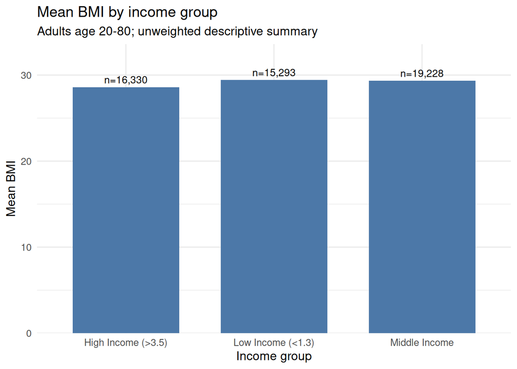

Mean BMI by income group among adults age 20-80 in the prepared classroom dataset. Values are unweighted and descriptive.

```r
# AI prompt: Generate a clear code-generated column chart of mean BMI by IncomeGroup and save the plot in the A9 outputs folder.
# Verified: The HTML chart is generated from the complete-case grouped data, and the exported PNG shows the same three mean values and income-group order.
plot_df <- analysis_df |>
  filter(!is.na(BMI), !is.na(IncomeGroup)) |>
  group_by(IncomeGroup) |>
  summarise(mean_bmi = mean(BMI), n = n(), .groups = "drop")

plot <- ggplot(plot_df, aes(x = IncomeGroup, y = mean_bmi)) +
  geom_col(fill = "#4C78A8", width = 0.72) +
  geom_text(aes(label = paste0("n=", scales::comma(n))), vjust = -0.5, size = 3.5) +
  labs(
    title = "Mean BMI by income group",
    subtitle = "Adults age 20-80; unweighted descriptive summary",
    x = "Income group",
    y = "Mean BMI"
  ) +
  scale_y_continuous(limits = c(0, 32), expand = expansion(mult = c(0, 0.05))) +
  theme_minimal(base_size = 12)

print(plot)
```

```r
ggsave(file.path(output_dir, "mean-bmi-by-income.png"), plot, width = 8, height = 5, dpi = 150)
```

## Plain-language summary

In this prepared classroom dataset, average BMI differed by income group among adults age 20-80. The low-income group had a mean BMI of 29.4, the middle-income group 29.3, and the high-income group 28.6. These descriptive differences may help frame health-equity questions, but they do not show that income caused BMI differences or that the same pattern applies to every U.S. adult. Missing BMI or income-group values were excluded from the grouped summary after missingness was checked.

## Limitations

- The source is a prepared classroom snapshot rather than raw NHANES microdata.
- The summaries are unweighted and should not be described as national estimates.
- The comparison is descriptive and does not test significance or control for measured confounders.
- Complete-case grouping may exclude records with missing BMI or income-group values.
- Group differences do not establish an individual-level or causal relationship.

## Technical appendix

The cohort definition is `Age >= 20 & Age <= 80`. Missingness is checked within the age cohort before complete-case BMI and income-group summaries. The generated CSV and PNG are written to `outputs/` so the evidence can be reused outside the HTML report.

```r
# AI prompt: Print the source, cohort, missingness, and income-group result counts needed to audit the technical appendix.
# Verified: These counts match the table and missingness outputs rendered earlier in the report.
tibble(
  Measure = c("Source rows", "Age cohort", "Missing BMI", "Missing IncomeGroup", "Complete-case rows"),
  Value = c(
    nrow(nhanes),
    nrow(analysis_df),
    sum(is.na(analysis_df$BMI)),
    sum(is.na(analysis_df$IncomeGroup)),
    nrow(analysis_df |> filter(!is.na(BMI), !is.na(IncomeGroup)))
  )
) |> kable(caption = "Technical audit counts.")
```

Technical audit counts.

| Measure | Value |
| --- | --- |
| Source rows | 105626 |
| Age cohort | 57137 |
| Missing BMI | 1009 |
| Missing IncomeGroup | 5395 |
| Complete-case rows | 50851 |

## References

Centers for Disease Control and Prevention, National Center for Health Statistics. 2026. *National Health and Nutrition Examination Survey*. https://wwwn.cdc.gov/nchs/nhanes/.